# Machine Learning Engineer Nanodegree

## Project: Build a Digit Recognition Program

In this notebook, a template is provided for you to implement your functionality in stages which is required to successfully complete this project. If additional code is required that cannot be included in the notebook, be sure that the Python code is successfully imported and included in your submission, if necessary. Sections that begin with **'Implementation'** in the header indicate where you should begin your implementation for your project. Note that some sections of implementation are optional, and will be marked with **'Optional'** in the header.

In addition to implementing code, there will be questions that you must answer which relate to the project and your implementation. Each section where you will answer a question is preceded by a **'Question'** header. Carefully read each question and provide thorough answers in the following text boxes that begin with **'Answer:'**. Your project submission will be evaluated based on your answers to each of the questions and the implementation you provide.

> **Note:** Code and Markdown cells can be executed using the **Shift + Enter** keyboard shortcut. In addition, Markdown cells can be edited by typically double-clicking the cell to enter edit mode.

## Step 1: Design and Test a Model Architecture

Design and implement a deep learning model that learns to recognize sequences of digits. Train the model using synthetic data generated by concatenating character images from [notMNIST](http://yaroslavvb.blogspot.com/2011/09/notmnist-dataset.html) or [MNIST](http://yann.lecun.com/exdb/mnist/). To produce a synthetic sequence of digits for testing, you can for example limit yourself to sequences up to five digits, and use five classifiers on top of your deep network. You would have to incorporate an additional ‘blank’ character to account for shorter number sequences.

There are various aspects to consider when thinking about this problem:

- Your model can be derived from a deep neural net or a convolutional network.
- You could experiment sharing or not the weights between the softmax classifiers.
- You can also use a recurrent network in your deep neural net to replace the classification layers and directly emit the sequence of digits one-at-a-time.

Here is an example of a [published baseline model on this problem](http://static.googleusercontent.com/media/research.google.com/en//pubs/archive/42241.pdf). ([video](https://www.youtube.com/watch?v=vGPI_JvLoN0))

### Implementation

Use the code cell (or multiple code cells, if necessary) to implement the first step of your project. Once you have completed your implementation and are satisfied with the results, be sure to thoroughly answer the questions that follow.

### Prepare Synthetic MNIST digit sequences

```
('Attempting to download:', 'train-images-idx3-ubyte.gz')
0%....5%....10%....15%....20%....25%....30%....35%....40%....45%....50%....55%....60%....65%....70%....75%....80%....85%....90%....95%....100%
Download Complete!
('Found and verified', './mnist_data/train-images-idx3-ubyte.gz')
('Attempting to download:', 'train-labels-idx1-ubyte.gz')
0%..85%.
Download Complete!
('Found and verified', './mnist_data/train-labels-idx1-ubyte.gz')
('Attempting to download:', 't10k-images-idx3-ubyte.gz')
0%....5%....10%....15%....20%....25%....30%....35%....40%....45%....50%....55%....60%....65%....70%....75%....80%....85%....90%....95%....100%
Download Complete!
('Found and verified', './mnist_data/t10k-images-idx3-ubyte.gz')
('Attempting to download:', 't10k-labels-idx1-ubyte.gz')
0%180%
Download Complete!
('Found and verified', './mnist_data/t10k-labels-idx1-ubyte.gz')
Skipping extraction of mnist_data/train-images-idx3-ubyte.gz.
Skipping extraction of mnist_data/train-labels-idx1-ubyte.gz.
Skipping extraction of mnist_data/t10k-images-idx3-ubyte.gz.
Skipping extraction of mnist_data/t10k-labels-idx1-ubyte.gz.
Display sample train image: index: 20146 label: 1
```

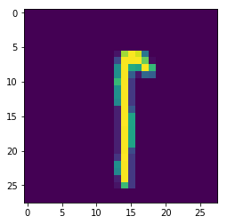

```
Display sample test image: index: 9596 label: 8
```

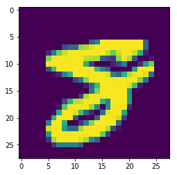

```python
### Generating Synthetic MNIST Data

#!/usr/bin/env python2
# -*- coding: utf-8 -*-

"""
#%%
"""

# import modules

import numpy as np
import os
import random
import sys
import gzip
import idx2numpy
import matplotlib.pyplot as plt
from IPython.display import display, Image
from scipy import ndimage
from scipy.misc import imsave
from sklearn.linear_model import LogisticRegression
from six.moves.urllib.request import urlretrieve
from six.moves import cPickle as pickle
from socket import socket

# global variables

idisplay = 1
num_merge = 5
img_height = 28
img_width = 28

np.random.seed(133)

# MNIST dataset
mnist_url = 'http://yann.lecun.com/exdb/mnist/'

#%%

# download, extract and display sample images

mnist_data = './mnist_data/'
if not os.path.isdir(mnist_data):
    print ('Creating dir:', mnist_data)
    os.mkdir(mnist_data)

# reused/modified from tensorflow 1_notmnist.ipynb

last_percent_reported = None
def download_progress_hook(count, blockSize, totalSize):
  """A hook to report the progress of a download. This is mostly intended for users with
  slow internet connections. Reports every 5% change in download progress.
  """
  global last_percent_reported
  percent = int(count * blockSize * 100 / totalSize)

  if last_percent_reported != percent:
    if percent % 5 == 0:
      sys.stdout.write("%s%%" % percent)
      sys.stdout.flush()
    else:
      sys.stdout.write(".")
      sys.stdout.flush()

    last_percent_reported = percent

def maybe_download(url, filename, expected_bytes, force=False):
  """Download a file if not present, and make sure it's the right size."""

  if force or not os.path.exists(filename):
    print('Attempting to download:', filename)
    filename, _ = urlretrieve(url+filename, mnist_data+filename, reporthook=download_progress_hook)
    print('\nDownload Complete!')

  statinfo = os.stat(filename)
  if statinfo.st_size == expected_bytes:
    print('Found and verified', filename)
  else:
    raise Exception(
      'Failed to verify ' + filename + '. Can you get to it with a browser?')
  return mnist_data+filename

mnist_train_images_gz = maybe_download(mnist_url, 'train-images-idx3-ubyte.gz', 9912422)
mnist_train_labels_gz = maybe_download(mnist_url, 'train-labels-idx1-ubyte.gz', 28881)
mnist_test_images_gz  = maybe_download(mnist_url, 't10k-images-idx3-ubyte.gz', 1648877)
mnist_test_labels_gz  = maybe_download(mnist_url, 't10k-labels-idx1-ubyte.gz', 4542)

def maybe_extract(filename):
    fname = os.path.splitext(os.path.splitext(filename)[0])[0]  # remove .tar.gz
    if os.path.isfile(fname):
        print('Skipping extraction of %s.' % (filename))
    else:
        print('Extracting %s ...' % (filename))
        cmd = 'gunzip {}'.format(filename)
        os.system(cmd)
    return fname

maybe_extract('mnist_data/train-images-idx3-ubyte.gz')
maybe_extract('mnist_data/train-labels-idx1-ubyte.gz')
maybe_extract('mnist_data/t10k-images-idx3-ubyte.gz')
maybe_extract('mnist_data/t10k-labels-idx1-ubyte.gz')

train_samples = idx2numpy.convert_from_file('mnist_data/train-images-idx3-ubyte')
train_labels  = idx2numpy.convert_from_file('mnist_data/train-labels-idx1-ubyte')
test_samples  = idx2numpy.convert_from_file('mnist_data/t10k-images-idx3-ubyte')
test_labels   = idx2numpy.convert_from_file('mnist_data/t10k-labels-idx1-ubyte')

def display_samples(data, labels, text=None, num_samples=1, idx='rand', squeeze=0):
    for i in range(num_samples):
        if idx == 'rand':
            idx = random.choice(range(data.shape[0]))

        print 'Display sample {} image: index: {} label: {}'.format(text, idx, labels[idx])
        if squeeze == 0:
            plt.imshow(data[idx], interpolation='nearest')
        else:
            plt.imshow(np.squeeze(data[idx], axis=(2,)), interpolation='nearest')

        plt.show()

if idisplay:
    display_samples(train_samples, train_labels, text='train', num_samples=1)
    display_samples(test_samples, test_labels, text='test', num_samples=1)
```

```
Display sample train image: index: 69290 label: [0 1 2 7 0 1]
```

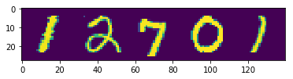

```
Display sample test image: index: 16043 label: [ 0  4  1  4 10 10]
```

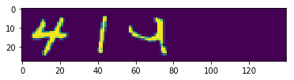

```python
def createSequences(data, labels, img_height, img_width, merge=5):
    num_merged = int(data.shape[0]/merge)
    nlabels = np.ndarray(shape=(data.shape[0]*2, merge+1), dtype=np.int32)
    ndata = np.ndarray(shape=(data.shape[0]*2, img_height, img_width*merge), dtype=np.float32)

    for i in range(merge*2):
        rand_idx = random.sample(range(0, data.shape[0]), data.shape[0])
        w = 0;
        for j in range(num_merged):
            a, b, c, d, e = rand_idx[w:w+merge]
            num_rand = random.choice(range(1,6))
            zeros = np.zeros([28,28])
            if num_rand == 5:
                ndata[(i*num_merged)+j,:,:] = np.concatenate([data[a],data[b],data[c],data[d],data[e]], axis=1)
                nlabels[(i*num_merged)+j,:] = np.hstack([0,labels[a],labels[b],labels[c],labels[d],labels[e]])
            elif num_rand == 4:
                ndata[(i*num_merged)+j,:,:] = np.concatenate([data[a],data[b],data[c],data[d],zeros], axis=1)
                nlabels[(i*num_merged)+j,:] = np.hstack([0,labels[a],labels[b],labels[c],labels[d],10])
            elif num_rand == 3:
                ndata[(i*num_merged)+j,:,:] = np.concatenate([data[a],data[b],data[c],zeros,zeros], axis=1)
                nlabels[(i*num_merged)+j,:] = np.hstack([0,labels[a],labels[b],labels[c],10,10])
            elif num_rand == 2:
                ndata[(i*num_merged)+j,:,:] = np.concatenate([data[a],data[b],zeros,zeros,zeros], axis=1)
                nlabels[(i*num_merged)+j,:] = np.hstack([0,labels[a],labels[b],10,10,10])
            elif num_rand == 1:
                ndata[(i*num_merged)+j,:,:] = np.concatenate([data[a],zeros,zeros,zeros,zeros], axis=1)
                nlabels[(i*num_merged)+j,:] = np.hstack([0,labels[a],10,10,10,10])
            w += merge

    # add dim for grey scale
    ndata = np.expand_dims(ndata, axis=3)

    return ndata, nlabels

m_train_samples, m_train_labels = createSequences(train_samples,
                                                  train_labels,
                                                  img_height=img_height,
                                                  img_width=img_width,
                                                  merge=num_merge)

m_test_samples, m_test_labels = createSequences(test_samples,
                                                test_labels,
                                                img_height=img_height,
                                                img_width=img_width,
                                                merge=num_merge)

if idisplay:
    display_samples(m_train_samples, m_train_labels, text='train', num_samples=1, squeeze=1)
    display_samples(m_test_samples, m_test_labels, text='test', num_samples=1, squeeze=1)
```

```python
mnist_merged = './mnist_merged/'
mnist_merged_train = './mnist_merged/merged_train'
mnist_merged_test  = './mnist_merged/merged_test'

if not os.path.isdir(mnist_merged):
    print ('Creating dir:', mnist_merged)
    os.mkdir(mnist_merged)
    os.mkdir(mnist_merged_train)
    os.mkdir(mnist_merged_test)

print 'Saving merged train images to: {} ...'.format(mnist_merged_train)
for i in range(m_train_samples.shape[0]):
    save_file = '{}/{}.png'.format(mnist_merged_train, i)
    imsave(save_file, (np.squeeze(m_train_samples[i], axis=(2,))))

print 'Saving merged test images to: {} ...'.format(mnist_merged_test)
for i in range(m_test_samples.shape[0]):
    save_file = '{}/{}.png'.format(mnist_merged_test, i)
    imsave(save_file, (np.squeeze(m_test_samples[i], axis=(2,))))

if idisplay:
    Image(filename='mnist_merged/merged_train/1.png')
    Image(filename='mnist_merged/merged_test/1.png')

# Save
m_train_samples_save = m_train_samples
m_train_labels_save = m_train_labels

# Create validation set (6000 of 60000)
nval = 6000
m_val_samples = np.ndarray(shape=(nval, img_height, img_width*num_merge), dtype=np.float32)
m_val_labels = np.ndarray(shape=(nval, num_merge), dtype=np.int32)

m_val_samples = m_train_samples[:nval,]
m_val_labels = m_train_labels[:nval,]
m_train_samples = np.delete(m_train_samples, np.r_[:nval], 0)
m_train_labels = np.delete(m_train_labels, np.r_[:nval], 0)

# Create Pickling File
print('Pickling data...')
pickle_file = 'mnist_merged/MNIST.merged.pickle'

print 'Train samples: {}'.format(m_train_samples.shape)
print 'Train labels: {}'.format(m_train_labels.shape)
print 'Validation samples: {}'.format(m_val_samples.shape)
print 'Validation labels: {}'.format(m_val_labels.shape)
print 'Test samples: {}'.format(m_test_samples.shape)
print 'Test labels: {}'.format(m_test_labels.shape)

try:
    f = open(pickle_file, 'wb')
    save = {
        'm_train_samples': m_train_samples,
        'm_train_labels': m_train_labels,
        'm_val_samples': m_val_samples,
        'm_val_labels': m_val_labels,
        'm_test_samples': m_test_samples,
        'm_test_labels': m_test_labels,
        }
    pickle.dump(save, f, pickle.HIGHEST_PROTOCOL)
    f.close()
except Exception as e:
    print('Unable to save data to {}: {}'.format(pickle_file, e))
    raise

statinfo = os.stat(pickle_file)
print('Success!')
print('Compressed pickle size: {}'.format(statinfo.st_size))
```

```
('Creating dir:', './mnist_merged/')
Saving merged train images to: ./mnist_merged/merged_train ...
Saving merged test images to: ./mnist_merged/merged_test ...
Pickling data...
Train samples: (114000, 28, 140, 1)
Train labels: (114000, 6)
Validation samples: (6000, 28, 140, 1)
Validation labels: (6000, 6)
Test samples: (20000, 28, 140, 1)
Test labels: (20000, 6)
Success!
Compressed pickle size: 2198560464
```

### MNIST : CNN Model to detect sequences up to 5 digits

```python
#!/usr/bin/env python2
# -*- coding: utf-8 -*-
"""
Created on Fri Jan 20 22:19:29 2017

@author: harik
"""

""""
MNIST MODEL:

    -------------------------------------------------------------------------------
    CNN Model Architecture for multi digit recognition implemented with TensorFlow
    -------------------------------------------------------------------------------
      inputs    [batch_size, 28, 140, 1]
      conv1     [patch=3x15, stride=1x1, padding=valid, 16 features]
      relu1     [relu]
      maxpool1  [patch=2x2, stride=2x2, padding=valid]
      conv2     [patch=4x20, stride=1x1, padding=valid, 32 features]
      relu2     [relu]
      maxpool2  [patch=2x2, stride=2x2, padding=valid]
      conv3     [patch=5x22, stride=1x1, padding=valid, 96 features]
      relu2     [relu]
      drop_out  10 %
      fc        [nodes=64]
      outputs   [y1,y2,y3,y4,y5]

SVHN MODEL:

    -------------------------------------------------------------------------------
    CNN Model Architecture for multi digit recognition implemented with TensorFlow
    -------------------------------------------------------------------------------
      inputs    [batch_size, 32, 32, 1]
      conv1     [patch=5x5, stride=1x1, padding=valid, 16 features]
      relu1     [relu]
      maxpool1  [patch=2x2, stride=2x2, padding=valid]
      conv2     [patch=5x5, stride=1x1, padding=valid, 32 features]
      relu2     [relu]
      maxpool2  [patch=2x2, stride=2x2, padding=valid]
      conv3     [patch=5x5, stride=1x1, padding=valid, 96 features]
      relu2     [relu]
      drop_out  20 %
      fc        [nodes=64]
      outputs   [y1,y2,y3,y4,y5]

"""

#%%

# program mode control

debug     = 1
idisplay  = 0
svhn_en   = 0
mnist_en  = 0
mydata_en = 1
restore_session = 1

if mnist_en:
    num_steps  = 7125
    num_val    = 6000
    num_tests  = 10000
    img_width  = 140
    img_height = 28
    predict_bbox = 0
    session_name = 'session/digit_recognizer.mnist.ckpt'
elif svhn_en or mydata_en:
    num_steps  = 60000
    num_val    = 5684
    num_tests  = 13068
    img_width  = 32
    img_height = 32
    predict_bbox = 1
    localized_data = 0

    if predict_bbox:
        string = 'MeanSqError'
    else:
        string = 'accuracy'

    if localized_data:
        session_name = 'session/digit_recognizer.localized.ckpt'
    elif predict_bbox:
        session_name = 'session/digit_recognizer.bbox.ckpt'
    else:
        session_name = 'session/digit_recognizer.full_image.ckpt'

if mydata_en:
    restore_session = 1

import math
import pickle
import random
import numpy as np
import tensorflow as tf

if idisplay:
    import matplotlib.pyplot as plt
    from PIL import Image
    from IPython.display import display

if mnist_en:
    print 'Loading MNIST pickled data...'
    pickle_file = 'mnist_merged/MNIST.merged.pickle'

    with open(pickle_file, 'rb') as f:
        save = pickle.load(f)
        X_train_samples = save['m_train_samples']
        y_train_samples = save['m_train_labels']
        X_val_samples   = save['m_val_samples']
        y_val_samples   = save['m_val_labels']
        X_test_samples  = save['m_test_samples']
        y_test_samples  = save['m_test_labels']
        del save
        print 'Training data shape: ', X_train_samples.shape
        print 'Training label shape:', y_train_samples.shape
        print 'Validation data shape:', X_val_samples.shape
        print 'Validation label shape:', y_val_samples.shape
        print 'Test data shape:     ', X_test_samples.shape
        print 'Test label shape:    ', y_test_samples.shape
        print 'Data successfully loaded !!'
elif svhn_en:
    print 'Loading SVHN pickled data...'
    pickle_file = 'svhn_data/SVHN.pickle'

    with open(pickle_file, 'rb') as f:
        save = pickle.load(f)

        if localized_data:
            X_train_samples = save['train_dataset']
            X_val_samples   = save['valid_dataset']
            X_test_samples  = save['test_dataset']
        else:
            X_train_samples = save['train_dataset_orig']
            X_val_samples   = save['valid_dataset_orig']
            X_test_samples  = save['test_dataset_orig']

        if predict_bbox:
            y_train_samples = save['train_bboxes']
            y_val_samples   = save['valid_bboxes']
            y_test_samples  = save['test_bboxes']
        else:
            y_train_samples = save['train_labels']
            y_val_samples   = save['valid_labels']
            y_test_samples  = save['test_labels']

        del save
        print 'Training data shape: ', X_train_samples.shape
        print 'Training label shape:', y_train_samples.shape
        print 'Validation data shape:', X_val_samples.shape
        print 'Validation label shape:', y_val_samples.shape
        print 'Test data shape:     ', X_test_samples.shape
        print 'Test label shape:    ', y_test_samples.shape
        print 'Data successfully loaded !!'

elif mydata_en:
    print 'Loading mydata pickled data...'
    pickle_file = 'my_data/my_data.pickle'

    with open(pickle_file, 'rb') as f:
        save = pickle.load(f)
        # load same data to train/val for placeholders
        X_train_samples = save['my_data']
        X_val_samples   = save['my_data']
        X_test_samples  = save['my_data']

        if predict_bbox:
            y_train_samples = save['my_bboxes']
            y_val_samples   = save['my_bboxes']
            y_test_samples  = save['my_bboxes']
        else:
            y_train_samples = save['my_labels']
            y_val_samples   = save['my_labels']
            y_test_samples  = save['my_labels']

        del save
        print 'Test data shape:     ', X_test_samples.shape
        print 'Test label shape:    ', y_test_samples.shape
        print 'Data successfully loaded !!'
```

[output not shown]

```
Display sample train image: 27069
```

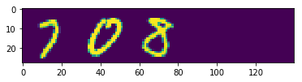

```
Display sample test image: 2877
```

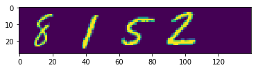

```python
if idisplay:
    def display_samples(num_samples=1):
        for i in range(num_samples):
            # train samples
            idx = random.choice(range(X_train_samples.shape[0]))
            print 'Display sample train image:', idx
            plt.imshow(X_train_samples[idx].reshape(img_height,img_width), interpolation='nearest')
            plt.show()

            # test samples
            idx = random.choice(range(X_test_samples.shape[0]))
            print 'Display sample test image:', idx
            plt.imshow(X_test_samples[idx].reshape(img_height,img_width), interpolation='nearest')
            plt.show()

    display_samples()
```

```python
if mnist_en:

    # params
    in_chan    = 1         # grey scale
    batch_size = 16        # batch size

    # conv1
    c1_patch_h = 3         # patch size 3x15
    c1_patch_w = 15        # patch size 3x15
    c1_depth   = 16        # 16 features (out channels)
    c1_padding = 'VALID' # padding valid
    c1_stride  = [1,1,1,1] # stride 1x1

    # maxpool1
    p1_padding = 'VALID'   # padding valid
    p1_patch   = [1,2,2,1] # patch size 2x2
    p1_stride  = [1,2,2,1] # stride 2x2

    # conv2
    c2_patch_h = 4         # patch size 4x20
    c2_patch_w = 20        # patch size 4x20
    c2_depth   = 32        # 32 features (out channels)
    c2_padding = 'VALID'   # padding valid
    c2_stride  = [1,1,1,1] # stride 1x1

    # maxpool2
    p2_padding = 'VALID'   # padding valid
    p2_patch   = [1,2,2,1] # patch size 2x2
    p2_stride  = [1,2,2,1] # stride 2x2

    # conv3
    c3_patch_h = 5         # patch size 5x22
    c3_patch_w = 22        # patch size 5x22
    c3_depth   = 96        # 96 features (out channels)
    c3_padding = 'VALID'   # padding valid
    c3_stride  = [1,1,1,1] # stride 1x1

    # fc
    keep_prob  = 0.9       # dropout rate
    fc_nodes   = 64        # hidden layer

    # output
    out_digits = 6         # up to 5 digits [1-5]
    out_labels = 11        # detect 0-9 & none

elif svhn_en or mydata_en:

    # params
    in_chan    = 1         # grey scale
    batch_size = 16        # batch size

    # conv1
    c1_patch_h = 5         # patch size 5x5
    c1_patch_w = 5         # patch size 5x5
    c1_depth   = 16        # 16 features (out channels)
    c1_padding = 'VALID'   # padding valid
    c1_stride  = [1,1,1,1] # stride 1x1

    # maxpool1
    p1_padding = 'VALID'   # padding valid
    p1_patch   = [1,2,2,1] # patch size 2x2
    p1_stride  = [1,2,2,1] # stride 2x2

    # conv2
    c2_patch_h = 5         # patch size 5x5
    c2_patch_w = 5         # patch size 5x5
    c2_depth   = 32        # 32 features (out channels)
    c2_padding = 'VALID'   # padding valid
    c2_stride  = [1,1,1,1] # stride 1x1

    # maxpool2
    p2_padding = 'VALID'   # padding valid
    p2_patch   = [1,2,2,1] # patch size 2x2
    p2_stride  = [1,2,2,1] # stride 2x2

    # conv3
    c3_patch_h = 5         # patch size 5x5
    c3_patch_w = 5         # patch size 5x5
    c3_depth   = 96        # 96 features (out channels)
    c3_padding = 'VALID'   # padding valid
    c3_stride  = [1,1,1,1] # stride 1x1

    # fc
    keep_prob  = 0.8       # dropout rate
    fc_nodes   = 64        # hidden layer

    # output
    out_digits = 6         # up to 5 digits [1-5]
    if predict_bbox:
        out_labels = 1     # regression (sigle value)
    else:
        out_labels = 11    # detect 0-9 & none


graph = tf.Graph()
with graph.as_default():

    # in, out place holders

    X_val  = tf.constant(X_val_samples)
    X_test = tf.constant(X_test_samples)

    if predict_bbox:
        Y = tf.placeholder(tf.float32, shape=(batch_size, out_digits))
    else:
        Y = tf.placeholder(tf.int32, shape=(batch_size, out_digits))

    X = tf.placeholder(tf.float32, shape=(batch_size, img_height, img_width, in_chan))

    # weights & biases

    def init_bias(name, shape):
        if predict_bbox and name == 'b_Y5':
            return tf.get_variable(name=name, initializer=tf.zeros(shape=shape))
        else:
            initializer = tf.contrib.layers.xavier_initializer()
            return tf.get_variable(shape=shape, name=name, initializer=initializer)

    def init_weight(name, shape):
        if predict_bbox and name == 'W_Y5':
            return tf.get_variable(name=name, initializer=tf.zeros(shape=shape))
        else:
            initializer = tf.contrib.layers.xavier_initializer_conv2d()
            return tf.get_variable(shape=shape, name=name, initializer=initializer)

    # pool_out = [(width or height) - patch]/(stride) + 1
    # conv_out = [(width or height) - patch + 2 * pad]/(stride) + 1
    def calc_out(w, h, p_w, p_h, stride, padding, type='conv'):
        pad = 1 if padding == 'SAME' else 0
        if type == 'pool':
            w_out = (w - p_w)/(stride) + 1
            h_out = (h - p_h)/(stride) + 1
        else:
            w_out = (w - p_w + 2 * pad)/(stride) + 1
            h_out = (h - p_h + 2 * pad)/(stride) + 1

        return w_out, h_out

    def calc_fc_size(im_w, im_h):
        (c1_w, c1_h) = calc_out(im_w, im_h, c1_patch_w,  c1_patch_h,  c1_stride[1], c1_padding, type='conv')
        (p1_w, p1_h) = calc_out(c1_w, c1_h, p1_patch[1], p1_patch[1], p1_stride[1], p1_padding, type='pool')
        (c2_w, c2_h) = calc_out(p1_w, p1_h, c2_patch_w,  c2_patch_h,  c2_stride[1], c2_padding, type='conv')
        (p2_w, p2_h) = calc_out(c2_w, c2_h, p2_patch[1], p2_patch[1], p2_stride[1], p2_padding, type='pool')
        (c3_w, c3_h) = calc_out(p2_w, p2_h, c3_patch_w,  c3_patch_h,  c3_stride[1], c3_padding, type='conv')

        print('Final image size after convolutions: {} x {}'.format(c3_w, c3_h))
        return c3_w, c3_h

    fc_w, fc_h = calc_fc_size(img_width, img_height)

    b_C1 = init_bias(name='b_C1', shape=[c1_depth])
    b_C2 = init_bias(name='b_C2', shape=[c2_depth])
    b_C3 = init_bias(name='b_C3', shape=[c3_depth])
    b_FC = init_bias(name='b_FC', shape=[fc_nodes])

    W_C1 = init_weight(name='W_C1', shape=[c1_patch_h, c1_patch_w, in_chan,  c1_depth])
    W_C2 = init_weight(name='W_C2', shape=[c2_patch_h, c2_patch_w, c1_depth, c2_depth])
    W_C3 = init_weight(name='W_C3', shape=[c3_patch_h, c3_patch_w, c2_depth, c3_depth])
    W_FC = init_weight(name='W_FC', shape=[fc_w * fc_h * c3_depth, fc_nodes])

    b_Y1 = init_bias(name='b_Y1', shape=[out_labels])
    b_Y2 = init_bias(name='b_Y2', shape=[out_labels])
    b_Y3 = init_bias(name='b_Y3', shape=[out_labels])
    b_Y4 = init_bias(name='b_Y4', shape=[out_labels])
    b_Y5 = init_bias(name='b_Y5', shape=[out_labels])

    W_Y1 = init_weight(name='W_Y1', shape=[fc_nodes, out_labels])
    W_Y2 = init_weight(name='W_Y2', shape=[fc_nodes, out_labels])
    W_Y3 = init_weight(name='W_Y3', shape=[fc_nodes, out_labels])
    W_Y4 = init_weight(name='W_Y4', shape=[fc_nodes, out_labels])
    W_Y5 = init_weight(name='W_Y5', shape=[fc_nodes, out_labels])

    # CNN Model
    def model(data, keep_prob):
        with tf.name_scope('layer_1'):
            c1_out = tf.nn.conv2d(data, W_C1, c1_stride, padding=c1_padding)
            r1_out = tf.nn.relu(c1_out + b_C1)
            p1_out = tf.nn.max_pool(r1_out, p1_patch, p1_stride, padding=p1_padding)

        with tf.name_scope('layer_2'):
            c2_out = tf.nn.conv2d(p1_out, W_C2, c2_stride, padding=c2_padding)
            r2_out = tf.nn.relu(c2_out + b_C2)
            p2_out = tf.nn.max_pool(r2_out, p2_patch, p2_stride, padding=p2_padding)

        with tf.name_scope('layer_3'):
            c3_out = tf.nn.conv2d(p2_out, W_C3, c3_stride, padding=c3_padding)
            r3_out = tf.nn.relu(c3_out + b_C3)
            d1_out = tf.nn.dropout(r3_out, keep_prob)

        with tf.name_scope('fc_layer'):
            shape   = d1_out.get_shape().as_list()
            reshape = tf.reshape(d1_out, [shape[0], shape[1] * shape[2] * shape[3]])
            fc_out  = tf.nn.relu(tf.matmul(reshape, W_FC) + b_FC)

        with tf.name_scope('fully_connected'):
            y1 = tf.matmul(fc_out, W_Y1) + b_Y1
            y2 = tf.matmul(fc_out, W_Y2) + b_Y2
            y3 = tf.matmul(fc_out, W_Y3) + b_Y3
            y4 = tf.matmul(fc_out, W_Y4) + b_Y4
            y5 = tf.matmul(fc_out, W_Y5) + b_Y5

        return [y1, y2, y3, y4, y5]

    # Loss function: cross_entropy
    [y1, y2, y3, y4, y5] = model(X, keep_prob)

    with tf.name_scope("cross_entropy"):
        if predict_bbox:
            # regression loss
            cross_entropy =  \
                             tf.reduce_mean(tf.square(y1 - Y[:,1])) +\
                             tf.reduce_mean(tf.square(y2 - Y[:,2])) +\
                             tf.reduce_mean(tf.square(y3 - Y[:,3])) +\
                             tf.reduce_mean(tf.square(y4 - Y[:,4]))
        else:
            cross_entropy = \
                            tf.reduce_mean(tf.nn.sparse_softmax_cross_entropy_with_logits(y1, Y[:, 1])) + \
                            tf.reduce_mean(tf.nn.sparse_softmax_cross_entropy_with_logits(y2, Y[:, 2])) + \
                            tf.reduce_mean(tf.nn.sparse_softmax_cross_entropy_with_logits(y3, Y[:, 3])) + \
                            tf.reduce_mean(tf.nn.sparse_softmax_cross_entropy_with_logits(y4, Y[:, 4])) + \
                            tf.reduce_mean(tf.nn.sparse_softmax_cross_entropy_with_logits(y5, Y[:, 5]))
        tf.summary.scalar("cross_entropy", cross_entropy)

    # Optimizer
    alpha = 0.05; learn_step = tf.Variable(0)
    learn = tf.train.exponential_decay(alpha, learn_step, 10000, 0.96)
    optimizer = tf.train.AdagradOptimizer(learn).minimize(cross_entropy, global_step=learn_step)

    def output_combine(data):
        if predict_bbox:
            y = tf.squeeze(tf.pack([model(data, 1.0)]))
        else:
            y = tf.pack([
                tf.nn.softmax(model(data, 1.0)[0]),
                tf.nn.softmax(model(data, 1.0)[1]),
                tf.nn.softmax(model(data, 1.0)[2]),
                tf.nn.softmax(model(data, 1.0)[3]),
                tf.nn.softmax(model(data, 1.0)[4])])
        return y

    y_pred      = output_combine(X)
    y_val_pred  = output_combine(X_val)
    y_test_pred = output_combine(X_test)

    # Save
    saver = tf.train.Saver()

    # weight histogram
    tf.summary.histogram("W_C1", W_C1)
    tf.summary.histogram("W_C2", W_C2)
    tf.summary.histogram("W_C3", W_C3)
    tf.summary.histogram("W_FC", W_FC)
    tf.summary.histogram("W_Y1", W_Y1)
    tf.summary.histogram("W_Y2", W_Y2)
    tf.summary.histogram("W_Y3", W_Y3)
    tf.summary.histogram("W_Y4", W_Y4)
    tf.summary.histogram("W_Y5", W_Y5)

    tf.summary.histogram("b_C1", b_C1)
    tf.summary.histogram("b_C2", b_C2)
    tf.summary.histogram("b_C3", b_C3)
    tf.summary.histogram("b_FC", b_FC)
    tf.summary.histogram("b_Y1", b_Y1)
    tf.summary.histogram("b_Y2", b_Y2)
    tf.summary.histogram("b_Y3", b_Y3)
    tf.summary.histogram("b_Y4", b_Y4)
    tf.summary.histogram("b_Y5", b_Y5)

    print('Graph done!')

#%%

def accuracy(predictions, labels, debug=0):
    if debug:
        for i in range(labels.shape[0]):
            if predict_bbox:
                np.set_printoptions(formatter={'float': '{: 0.1f}'.format})
                print 'Test ',i+1,':', predictions.T[i,0:4], labels[i,0:4]
            else:
                print 'Test ',i+1,':', np.argmax(predictions, 2).T[i], labels[i]

    if predict_bbox:
        return ((predictions.T[:,0:3] - labels[:,0:3]) ** 2).mean(axis=None)
    else:
        return (100.0 * np.sum(np.argmax(predictions, 2).T == labels)
                / predictions.shape[1] / predictions.shape[0])

def get_offset(step, batch_size, data):
    offset = (step * batch_size) % (data.shape[0] - batch_size)
    return offset

def model_loop(X_samples, y_samples, num_steps=1, debug=0):
    for step in range(num_steps):
        offset  = get_offset(step, batch_size, y_samples)
        batch_X = X_samples[offset:(offset + batch_size), :, :, :]
        batch_Y = y_samples[offset:(offset + batch_size), :]
        feed_dict = {X: batch_X, Y: batch_Y}

        _, loss, pred, summary = sess.run([optimizer, cross_entropy, y_pred, merged], feed_dict=feed_dict)

        writer.add_summary(summary)

        if (step % 250 == 0):
            print (('step {}: loss -> {} {} -> {}').format(step, round(loss,2), string, accuracy(pred, batch_Y[:,1:6], debug=debug),))
            print (('Validation {}: {}'.format(string, round(accuracy(y_val_pred.eval(), y_val_samples[:,1:6], debug=debug), 2))))
```

```
Final image size after convolutions: 1 x 1
Graph done!
```

```python
#### Dont run this cell on normal machines

with tf.Session(graph=graph) as sess:
    writer = tf.summary.FileWriter("log", sess.graph)
    merged = tf.summary.merge_all()
    sess.run(tf.global_variables_initializer())

    if restore_session:
        print('Restoring session: ', session_name)
        saver.restore(sess, session_name)
    else:
        # train loops
        print ('Start training: batch_size {} num_steps {}').format(batch_size, num_steps)
        model_loop(X_train_samples, y_train_samples, num_steps, debug=0)

    # test accuracy
    print ('Start Testing: num_tests {}').format(num_tests)
    print (('Test {}: {}'.format(string, accuracy(y_test_pred.eval(), y_test_samples[:,1:6], debug=debug))))

    # save session
    save_path = saver.save(sess, "session/digit_recognizer.ckpt")
    print('Model saved to file: {}'.format(save_path))

print('Tensorboard: tensorboard --logdir=log')
```

### Excerpts from logfile : submission/mnist.run.log

Loading MNIST pickled data...

Training data shape: (114000, 28, 140, 1)

Training label shape: (114000, 6)

Validation data shape: (6000, 28, 140, 1)

Validation label shape: (6000, 6)

Data successfully loaded !!

Final image size after convolutions: 1 x 1

Graph done!

Start training: batch_size 16 num_steps 7125

step 0: loss -> 77.57 accuracy -> 1.25%

Validation accuracy: 39.42%

...............

Validation accuracy: 89.86%

step 6750: loss -> 1.53 accuracy -> 96.25%

Validation accuracy: 89.74%

step 7000: loss -> 2.46 accuracy -> 87.5%

**Validation accuracy: 89.53%**

Start Testing: num_tests 10000

[ 8 4 2 10 10] [ 3 4 2 10 10]

[ 9 6 4 10 10] [ 9 6 4 10 10]

[ 0 3 10 10 10] [ 0 3 10 10 10]

[3 5 0 7 7] [3 5 0 9 2]

[ 4 10 10 10 10] [ 4 10 10 10 10]

[ 3 10 10 10 10] [ 3 10 10 10 10]

[1 9 3 7 7] [1 9 3 2 7]

..................

[ 3 4 6 10 10] [ 8 4 6 10 10]

[ 9 10 10 10 10] [ 9 10 10 10 10]

**Test accuracy: 90.695%**

Model saved to file: session/digit_recognizer.ckpt

Tensorboard: tensorboard --logdir=log

#### Full logfile: submission/mnist.run.log

### Question 1

*What approach did you take in coming up with a solution to this problem?*

**Answer:**

**Following are the steps involved in building a digit recognition model**

- Step1: Create synthetic data by concatenating up to 5 digits from MNIST dataset
- Step2: Create pickle file with train, validation, and test samples
- Step3: Load pickle files and display sample data for sanity
- Step4: Use Tensor flow to create a CNN and train the model and compute validation accuracy
- Step5: Run the model on test set and compute accuracy

**Choice of implementation: Tensorflow VS Keras/Theano**

- I implemented the first version of the model using Keras/Theano, I quickly got stuck with trying to debug the model, at which point I realized there is not a lot of support on the web since most people are now using Tensorflow
- First I did these tutorials for classifying multi digit MNIST from tensorflow.org. There is also interesting insigths from PythonProgramming
  - **Tensorflow.org**: MNIST for ML Begineers: https://www.tensorflow.org/tutorials/mnist/beginners/
  - **Tensorflow.org**: Deep MNIST for Experts: https://www.tensorflow.org/tutorials/mnist/pros/
  - **PythonProgramming.net**: CNN TensorFlow tutorial: https://pythonprogramming.net/cnn-tensorflow-convolutional-nerual-network-machine-learning-tutorial/

**Choice of model selection: CNN vs DNN vs SVM**

- Researched a number of image classification models on the web. All image classification models today use deep neural networks (specifically CNN). Altough it is possible to implement the mode using fully connected deep neural nets, or SVM, CNN's are most efficient for image classification

**Choice of number of convolution layers:**

- 3 layer convolution network seems to be the most common for small image classification (up to 32x32 image sizes). I did not try to use more convolution layers.

**Choice of activation functions:**

- Research indicated RELU is the most commonly used activation fuction, I did not try using sigmoid or tanh

**Chioce of patch, stride's for convolution and pooling layers; Choice of number of fully connected layers**

- The difficult part was determining the CONV and POOL layers stride, patches for MNIST concatenated dataset because of the rectilinear size of the images when concatenated (28 x 28 * 5)
- Used this reference below to select patch and strides for convolution and pooling layers. This is one of the best resources for determining number of hidden layers, size of strides and patches
  - CNN for Visual Recognition: http://cs231n.github.io/convolutional-networks/

**Reference models for implementation**

- Ritchie Ng: https://github.com/ritchieng/NumNum

### Question 2

*What does your final architecture look like? (Type of model, layers, sizes, connectivity, etc.)*

**Answer:**

```
-------------------------------------------------------------------------------------
CNN Model Architecture for MNIST multi digit recognition implemented with TensorFlow
-------------------------------------------------------------------------------------
  inputs    [batch_size, 28, 140, 1]
  conv1     [patch=3x15, stride=1x1, padding=valid, 16 features]
  relu1     [relu]
  maxpool1  [patch=2x2, stride=2x2, padding=valid]
  conv2     [patch=4x20, stride=1x1, padding=valid, 32 features]
  relu2     [relu]
  maxpool2  [patch=2x2, stride=2x2, padding=valid]
  conv3     [patch=5x22, stride=1x1, padding=valid, 96 features]
  relu2     [relu]
  drop_out  10 %
  fc        [nodes=64]
  outputs   [y1,y2,y3,y4,y5]
```

### Question 3

*How did you train your model? How did you generate your synthetic dataset?* Include examples of images from the synthetic data you constructed.

**Answer:**

**How did you train your model?**

- Model was trained using synthetic data generated up to 5 digits from MNIST data set

Please provide a detailed description of your process for generating synthetic data.

**Steps involved in genrating synthetic data**

- Full code can be found in : load_mnist_data.py
- Download MNIST dataset and extract data (check size matches expected)
- Select a random number of digits to concatenate (random range 1 - 5 images)
  - num_rand = random.choice(range(1,6))
- Select random images index to concatenate
  - rand_idx = random.sample(range(0, data.shape[0]), data.shape[0])
- Use np.concatenate to concatenate data; use np.hstack to concatenate labels
  - ndata[(i*num_merged)+j,:,:] = np.concatenate([data[a],data[b],data[c],data[d],data[e]], axis=1)
  - nlabels[(i*num_merged)+j,:] = np.hstack([0,labels[a],labels[b],labels[c],labels[d],labels[e]])

**Examples of generated concatenated images**

```
Display sample train image: 16071
```

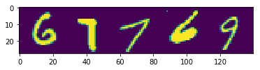

```
Display sample test image: 1357
```

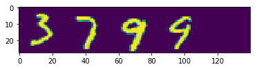

```python
display_samples()
```

## Step 2: Train a Model on a Realistic Dataset

Once you have settled on a good architecture, you can train your model on real data. In particular, the [Street View House Numbers (SVHN)](http://ufldl.stanford.edu/housenumbers/) dataset is a good large-scale dataset collected from house numbers in Google Street View. Training on this more challenging dataset, where the digits are not neatly lined-up and have various skews, fonts and colors, likely means you have to do some hyperparameter exploration to perform well.

### Implementation

Use the code cell (or multiple code cells, if necessary) to implement the first step of your project. Once you have completed your implementation and are satisfied with the results, be sure to thoroughly answer the questions that follow.

```python
#!/usr/bin/env python2
# -*- coding: utf-8 -*-
"""
Created on Sat Jan 21 11:05:22 2017

@author: harik
"""

#%%

# import modules

from __future__ import print_function
import matplotlib.pyplot as plt
import numpy as np
import os
import random
import sys
import tarfile
import h5py
from IPython.display import display, Image
from scipy import ndimage
from sklearn.linear_model import LogisticRegression
from six.moves.urllib.request import urlretrieve
from six.moves import cPickle as pickle
from PIL import Image

skip_download = 1
skip_extract = 1
np.random.seed(133)

#%%

# MNIST dataset

# SVHN dataset
svhn_url = 'http://ufldl.stanford.edu/housenumbers/'

#%%

# download, extract and display sample images

svhn_data = './svhn_data/'
if not os.path.isdir(svhn_data):
    print ('Creating dir:', svhn_data)
    os.mkdir(svhn_data)

# reused/modified from tensorflow 1_notmnist.ipynb

last_percent_reported = None
def download_progress_hook(count, blockSize, totalSize):
  """A hook to report the progress of a download. This is mostly intended for users with
  slow internet connections. Reports every 5% change in download progress.
  """
  global last_percent_reported
  percent = int(count * blockSize * 100 / totalSize)

  if last_percent_reported != percent:
    if percent % 5 == 0:
      sys.stdout.write("%s%%" % percent)
      sys.stdout.flush()
    else:
      sys.stdout.write(".")
      sys.stdout.flush()

    last_percent_reported = percent


def maybe_download(url, filename, expected_bytes, force=False):
  """Create dir if not present"""
  """Download a file if not present, and make sure it's the right size."""

  if force or not os.path.exists(filename):
    print('Attempting to download:', filename)
    filename, _ = urlretrieve(url+filename, filename, reporthook=download_progress_hook)
    print('\nDownload Complete!')

  statinfo = os.stat(filename)
  if statinfo.st_size == expected_bytes:
    print('Found and verified', filename)
  else:
    raise Exception(
      'Failed to verify ' + filename + '. Can you get to it with a browser?')
  return filename

if skip_download:
    print('Skipping download ...')
    svhn_train_filename = 'train.tar.gz'
    svhn_test_filename = 'test.tar.gz'
    svhn_extra_filename = 'extra.tar.gz'
else:
    svhn_train_filename = Maybe_download(svhn_url, 'train.tar.gz', 404141560)
    svhn_test_filename = maybe_download(svhn_url, 'test.tar.gz', 276555967)
    svhn_extra_filename = maybe_download(svhn_url, 'extra.tar.gz', 1955489752)

def maybe_extract(filename, force=False):
  global svhn_data
  root = os.path.splitext(os.path.splitext(filename)[0])[0]  # remove .tar.gz
  if os.path.isdir(root) and not force:
    # You may override by setting force=True.
    print('%s already present - Skipping extraction of %s.' % (root, filename))
  else:
    print('Extracting data for %s. This may take a while. Please wait.' % root)
    tar = tarfile.open(filename)
    sys.stdout.flush()
    tar.extractall(path=svhn_data)
    tar.close()
  return root

if skip_extract:
    print('Skipping extract ...')
    svhn_train_folder = 'svhn_data/train'
    svhn_test_folder  = 'svhn_data/test'
    svhn_extra_folder = 'svhn_data/extra'
else:
    svhn_train_folder = 'svhn_data/' + maybe_extract(svhn_train_filename)
    svhn_test_folder  = 'svhn_data/' + maybe_extract(svhn_test_filename)
    svhn_extra_folder = 'svhn_data/' + maybe_extract(svhn_extra_filename)

def display_samples(data_folder, num_samples=1):
    for i in range(num_samples):
        im_name = random.choice(os.listdir(data_folder))
        im_file = data_folder + "/" + im_name
        #display(Image(filename=im_file))

#display_samples(svhn_train_folder)
#display_samples(svhn_test_folder)
#display_samples(svhn_extra_folder)

#%%

# resued/modified: from https://github.com/ritchieng/NumNum/NumNum/load_data.py

# Create dictionary for bounding boxes
print('Creating dictionary of bounding boxes...')
class DigitStructFile:
    def __init__(self, inf):
        self.inf = h5py.File(inf, 'r')
        self.digitStructName = self.inf['digitStruct']['name']
        self.digitStructBbox = self.inf['digitStruct']['bbox']

    def getName(self,n):
        return ''.join([chr(c[0]) for c in self.inf[self.digitStructName[n][0]].value])

    def bboxHelper(self,attr):
        if (len(attr) > 1):
            attr = [self.inf[attr.value[j].item()].value[0][0] for j in range(len(attr))]
        else:
            attr = [attr.value[0][0]]
        return attr

    def getBbox(self,n):
        bbox = {}
        bb = self.digitStructBbox[n].item()
        bbox['height'] = self.bboxHelper(self.inf[bb]["height"])
        bbox['label'] = self.bboxHelper(self.inf[bb]["label"])
        bbox['left'] = self.bboxHelper(self.inf[bb]["left"])
        bbox['top'] = self.bboxHelper(self.inf[bb]["top"])
        bbox['width'] = self.bboxHelper(self.inf[bb]["width"])
        return bbox

    def getDigitStructure(self,n):
        s = self.getBbox(n)
        s['name']=self.getName(n)
        return s

    def getAllDigitStructure(self):
        return [self.getDigitStructure(i) for i in range(len(self.digitStructName))]

    def getAllDigitStructure_ByDigit(self):
        pictDat = self.getAllDigitStructure()
        result = []
        structCnt = 1
        for i in range(len(pictDat)):
            item = { 'filename' : pictDat[i]["name"] }
            figures = []
            for j in range(len(pictDat[i]['height'])):
               figure = {}
               figure['height'] = pictDat[i]['height'][j]
               figure['label']  = pictDat[i]['label'][j]
               figure['left']   = pictDat[i]['left'][j]
               figure['top']    = pictDat[i]['top'][j]
               figure['width']  = pictDat[i]['width'][j]
               figures.append(figure)
            structCnt = structCnt + 1
            item['boxes'] = figures
            result.append(item)
        return result

print("Successfully created dictionary of bounding boxes!")

# Get Digit Structure
print('Getting digit structure for training data...')
digitFileTrain=DigitStructFile(os.path.join(svhn_train_folder,'digitStruct.mat'))
train_data=digitFileTrain.getAllDigitStructure_ByDigit()
print('Success!')
```

```python
print('Getting digit structure for test data...')
digitFileTest=DigitStructFile(os.path.join(svhn_test_folder,'digitStruct.mat'))
test_data=digitFileTest.getAllDigitStructure_ByDigit()
print('Success!')

print('Getting digit structure for extra data...')
digitFileExtra=DigitStructFile(os.path.join(svhn_extra_folder,'digitStruct.mat'))
extra_data=digitFileExtra.getAllDigitStructure_ByDigit()
print('Success!')

# Crop Training Images
print('Cropping training images...')
train_imsize = np.ndarray([len(train_data),2])
for i in np.arange(len(train_data)):
    filename = train_data[i]['filename']
    fullname = os.path.join(svhn_train_folder, filename)
    im = Image.open(fullname)
    train_imsize[i, :] = im.size[:]

print('Success!')

# Crop Test Images
print('Cropping test images...')
test_imsize = np.ndarray([len(test_data),2])
for i in np.arange(len(test_data)):
    filename = test_data[i]['filename']
    fullname = os.path.join(svhn_test_folder, filename)
    im = Image.open(fullname)
    test_imsize[i, :] = im.size[:]

print('Success!')

# Crop Extra Images
print('Cropping extra images...')
extra_imsize = np.ndarray([len(extra_data),2])
for i in np.arange(len(extra_data)):
    filename = extra_data[i]['filename']
    fullname = os.path.join(svhn_extra_folder, filename)
    im = Image.open(fullname)
    extra_imsize[i, :] = im.size[:]

print('Success!')


def generate_dataset(data, folder):
    dataset = np.ndarray([len(data),32,32,1], dtype='float32')
    dataset_orig = np.ndarray([len(data),32,32,1], dtype='float32')
    labels = np.ones([len(data),6], dtype=int) * 10
    bboxes = np.zeros([len(data),6], dtype='float32')
    for i in np.arange(len(data)):
        filename = data[i]['filename']
        fullname = os.path.join(folder, filename)
        im = Image.open(fullname)
        boxes = data[i]['boxes']
        num_digit = len(boxes)
        labels[i,0] = num_digit
        top = np.ndarray([num_digit], dtype='float32')
        left = np.ndarray([num_digit], dtype='float32')
        height = np.ndarray([num_digit], dtype='float32')
        width = np.ndarray([num_digit], dtype='float32')
        for j in np.arange(num_digit):
            if j < 5:
                labels[i,j+1] = boxes[j]['label']
                if boxes[j]['label'] == 10: labels[i,j+1] = 0
            else: print('#',i,'image has more than 5 digits.')
            top[j] = boxes[j]['top']
            left[j] = boxes[j]['left']
            height[j] = boxes[j]['height']
            width[j] = boxes[j]['width']

        im_top = np.amin(top)
        im_left = np.amin(left)
        im_height = np.amax(top) + height[np.argmax(top)] - im_top
        im_width = np.amax(left) + width[np.argmax(left)] - im_left

        im_top = int(np.floor(im_top - 0.1 * im_height))
        im_left = int(np.floor(im_left - 0.1 * im_width))
        im_bottom = int(np.amin([np.ceil(im_top + 1.2 * im_height), im.size[1]]))
        im_right = int(np.amin([np.ceil(im_left + 1.2 * im_width), im.size[0]]))
        bboxes[i,:] = [0, im_top, im_left, im_bottom, im_right, 0]

        im_orig = im
        im_orig = im_orig.resize((32, 32), Image.ANTIALIAS)
        im_orig = np.dot(np.array(im_orig, dtype='float32'), [[0.2989],[0.5870],[0.1140]])
        mean = np.mean(im_orig, dtype='float32')
        std = np.std(im_orig, dtype='float32', ddof=1)
        if std < 1e-4: std = 1.
        im_orig = (im_orig - mean) / std
        dataset_orig[i,:,:,:] = im_orig[:,:,:]

        im = im.crop((im_left, im_top, im_right, im_bottom)).resize([32,32], Image.ANTIALIAS)
        im = np.dot(np.array(im, dtype='float32'), [[0.2989],[0.5870],[0.1140]])
        mean = np.mean(im, dtype='float32')
        std = np.std(im, dtype='float32', ddof=1)
        if std < 1e-4: std = 1.
        im = (im - mean) / std
        dataset[i,:,:,:] = im[:,:,:]

    return dataset, dataset_orig, labels, bboxes

print('Generating training dataset and labels...')
train_dataset, train_dataset_orig, train_labels, train_bboxes = generate_dataset(train_data, svhn_train_folder)
print('Success! \n Training set: {} \n Training orig set: {} \n Training labels: {} \n Training bboxes: {}'.format(train_dataset.shape, train_dataset_orig.shape, train_labels.shape, train_bboxes.shape))

print('Generating testing dataset and labels...')
test_dataset, test_dataset_orig, test_labels, test_bboxes = generate_dataset(test_data, svhn_test_folder)
print('Success! \n Test set: {} \n Test orig set: {} \n Test labels: {} \n Test bboxes: {}'.format(test_dataset.shape, test_dataset_orig.shape, test_labels.shape, test_bboxes.shape))

print('Generating extra dataset and labels...')
extra_dataset, extra_dataset_orig, extra_labels, extra_bboxes = generate_dataset(extra_data, svhn_extra_folder)
print('Success! \n Extra set: {} \n Extra orig set: {} \n Extra labels: {} \n Extra bboxes: {}'.format(extra_dataset.shape, extra_dataset_orig.shape, extra_labels.shape, extra_bboxes.shape))

# Clean up data by deleting digits more than 5 (very few)
print('Cleaning up training data...')
train_dataset = np.delete(train_dataset, 29929, axis=0)
train_dataset_orig = np.delete(train_dataset_orig, 29929, axis=0)
train_labels = np.delete(train_labels, 29929, axis=0)
train_bboxes = np.delete(train_bboxes, 29929, axis=0)
print('Success!')

#%%
# Expand Training Data
print('Expanding training data randomly...')

random.seed(8)

n_labels = 10
valid_index = []
valid_index2 = []
train_index = []
train_index2 = []
for i in np.arange(n_labels):
    valid_index.extend(np.where(train_labels[:,1] == (i))[0][:400].tolist())
    train_index.extend(np.where(train_labels[:,1] == (i))[0][400:].tolist())
    valid_index2.extend(np.where(extra_labels[:,1] == (i))[0][:200].tolist())
    train_index2.extend(np.where(extra_labels[:,1] == (i))[0][200:].tolist())

random.shuffle(valid_index)
random.shuffle(train_index)
random.shuffle(valid_index2)
random.shuffle(train_index2)

valid_dataset = np.concatenate((extra_dataset[valid_index2,:,:,:], train_dataset[valid_index,:,:,:]), axis=0)
valid_dataset_orig = np.concatenate((extra_dataset_orig[valid_index2,:,:,:], train_dataset_orig[valid_index,:,:,:]), axis=0)
valid_labels = np.concatenate((extra_labels[valid_index2,:], train_labels[valid_index,:]), axis=0)
valid_bboxes = np.concatenate((extra_bboxes[valid_index2,:], train_bboxes[valid_index,:]), axis=0)
```

```python
train_dataset_new = np.concatenate((extra_dataset[train_index2,:,:,:], train_dataset[train_index,:,:,:]), axis=0)
train_dataset_orig_new = np.concatenate((extra_dataset_orig[train_index2,:,:,:], train_dataset_orig[train_index,:,:,:]), axis=0)
train_labels_new = np.concatenate((extra_labels[train_index2,:], train_labels[train_index,:]), axis=0)
train_bboxes_new = np.concatenate((extra_bboxes[train_index2,:], train_bboxes[train_index,:]), axis=0)

print('Success! \n Training set: {} \n Training labels: {}'.format(train_dataset_new.shape, train_dataset_orig_new.shape, train_labels_new.shape, train_bboxes_new.shape))
print('Success! \n Validation set: {} \n Validation labels: {}'.format(valid_dataset.shape, valid_labels.shape, valid_bboxes.shape))
print('Success! \n Testing set: {} \n Testing labels: {}'.format(test_dataset.shape, test_labels.shape, test_bboxes.shape))

#%%

# Create Pickling File
print('Pickling data...')
pickle_file = 'svhn_data/SVHN.pickle'

try:
    f = open(pickle_file, 'wb')
    save = {
        'train_dataset': train_dataset,
        'train_dataset_orig': train_dataset_orig,
        'train_labels': train_labels,
        'train_bboxes': train_bboxes,
        'valid_dataset': valid_dataset,
        'valid_dataset_orig': valid_dataset_orig,
        'valid_labels': valid_labels,
        'valid_bboxes': valid_bboxes,
        'test_dataset': test_dataset,
        'test_dataset_orig': test_dataset_orig,
        'test_labels': test_labels,
        'test_bboxes': test_bboxes,
        }
    pickle.dump(save, f, pickle.HIGHEST_PROTOCOL)
    f.close()
except Exception as e:
    print('Unable to save data to {}: {}'.format(pickle_file, e))
    raise

statinfo = os.stat(pickle_file)
print('Success!')
print('Compressed pickle size: {}'.format(statinfo.st_size))
```

[output not shown]

### Question 4

*Describe how you set up the training and testing data for your model. How does the model perform on a realistic dataset?*

**Answer:**

**Steps involved in generating SVHN data**

- Full code can be found in : load_svhn_data.py
- Download SVHN dataset and extract data (check size matches expected)
- There are 3 sets of data: Train, Test and Extra
- Extract localization details and labels
  - Extract bounding boxes from digitStruct['bbox']
  - Extract labels boxes from digitStruct['name']
- Calculate total bounding box for all digits
- Crop images per the new calculated bounding box covering all digits
- Use extra images to add more train and validation samples
- Pack and data to a PICKLE file: svhn_data/SVHN.pickle

**Did you use the exact model you develop on the synthetic data on the SVHN?**

The structure of the model is same for MNIST and SVHN data but there are some changes in CONV and POOL layer filter sizes given the input data is 28x140 for MNIST and 32x32 for SVHN.

Comparison between MNIST and SVHN models. All the differences are to take in to account that MNIST model uses synthetic data created by concatenating 5 images of 28x28 size

[output not shown]

**Equations to calculate size of output layers:**

- pool_out = [(width or height) - patch]/(stride) + 1
- conv_out = [(width or height) - patch + 2 * pad]/(stride) + 1

**Steps for SVHN Model:**

- Step1: Used the bounding boxes and cropped the images to 32x32 pixels
- Step2: Split up the data in the training (33401), validation (5684) and test (13068) sets
- Train the model and compute track accuracy on validation set
- Run the model to compute accuracy on test set

The model performed better on the realistic data

SVHN MODEL:

```
-------------------------------------------------------------------------------
CNN Model Architecture for multi digit recognition implemented with TensorFlow
-------------------------------------------------------------------------------
  inputs    [batch_size, 32, 32, 1]
  conv1     [patch=5x5, stride=1x1, padding=valid, 16 features]
  relu1     [relu]
  maxpool1  [patch=2x2, stride=2x2, padding=valid]
  conv2     [patch=5x5, stride=1x1, padding=valid, 32 features]
  relu2     [relu]
  maxpool2  [patch=2x2, stride=2x2, padding=valid]
  conv3     [patch=5x5, stride=1x1, padding=valid, 96 features]
  relu2     [relu]
  drop_out  20 %
  fc        [nodes=64]
  outputs   [y1,y2,y3,y4,y5]
```

Please provide details of your preprocessing of the SVHN dataset.

### Question 5

*What changes did you have to make, if any, to achieve "good" results? Were there any options you explored that made the results worse?*

**Answer:**

**Which optimizers did you try? Why did you settle on adagrad? Describe your randomization of biases.**

**Choice of optimizer:**

- Initial trials were using SGD and later switched to AdaGrad. SGD seems to be doing a good job for single digit classification, AdaGrad outperforms SGD for multi-label classification. I am yet to understand why AdaGrad performs better for multi-label classification.

**Choice of Initialization:**

- Final implementation uses Xavier Initialization. Initial implementation uses const (1.0) initialization for bias terms, randomizing biases improves model performace

**What dropout rates did you try?**

- Initial implementation used a drop rate of 50%. Later tried other rates and eventually finalized on 10% which gave best performance

**What batch sizes and step sizes did you try?**

- Tried various combination of batch sizes & step sizes

| Trial | Batch Size | Num Steps | Comments |
| --- | --- | --- | --- |
| initial trials | sizes 1 - 16 | steps 10000 - 60000 | Train/validation rates improve by increasing batch size |
| Finalized values | 16 | 60000 | Best performace with this combination |

**A number of model architectures and parameters were explored. Below are the changes that achieved good results:**

- Randomizing intial values for weights and biases. Initializing bias to 1 made it worse
- Adding drop out (10-20%) prior to fully connected layer. No drop out made it worse
- Trying differnt filter sizes for conv layers. Can not decude much from filter sizes
- Tring differnt batch sizes and number of steps. smaller batch sizes made it worse

### Question 6

*What were your initial and final results with testing on a realistic dataset? Do you believe your model is doing a good enough job at classifying numbers correctly?*

**Answer:**

**What were your initial and final results with testing on a realistic dataset?**

[output not shown]

**Do you believe your model is doing a good enough job at classifying numbers correctly?**

- Results of the run below. The model is doing a reasonable job for digit sequences of up to 3 digits, does not perform as well for 4, 5 digit sequences. Lot more can be tried and improved. All these runs were done on GoogleCloud with CPU machines. Will need access to good GPU compute machines to improve run times to try multiple things

### Excerpts from logfile : submission/svhn.run.log

Loading SVHN pickled data...

Training data shape: (33401, 32, 32, 1)

Training label shape: (33401, 6)

Validation data shape: (5684, 32, 32, 1)

Validation label shape: (5684, 6)

Test data shape: (13068, 32, 32, 1)

Test label shape: (13068, 6)

Data successfully loaded !!

Final image size after convolutions: 1 x 1

Graph done!

Start training: batch_size 16 num_steps 60000

step 0: loss -> 11.95 accuracy -> 21.25%

Validation accuracy: 38.08%

step 250: loss -> 4.45 accuracy -> 71.25% ................

**Validation accuracy: 93.39%**

Start Testing: num_tests 13068

Test i: [ 5 10 10 10 10] [ 5 10 10 10 10]

Test i: [ 2 1 8 10 10] [ 2 1 0 10 10]

Test i: [ 6 10 10 10 10] [ 6 10 10 10 10]

........................................

Test i: [ 6 7 10 10 10] [ 6 7 10 10 10]

**Test accuracy: 91.4233241506%**

Model saved to file: session/digit_recognizer.ckpt

Tensorboard: tensorboard --logdir=log

## Step 3: Test a Model on Newly-Captured Images

Take several pictures of numbers that you find around you (at least five), and run them through your classifier on your computer to produce example results. Alternatively (optionally), you can try using OpenCV / SimpleCV / Pygame to capture live images from a webcam and run those through your classifier.

### Implementation

Use the code cell (or multiple code cells, if necessary) to implement the first step of your project. Once you have completed your implementation and are satisfied with the results, be sure to thoroughly answer the questions that follow.

```
[ 0  5 10 10 10 10]
```

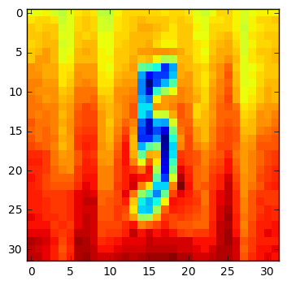

```
[ 0  2  1  0 10 10]
```

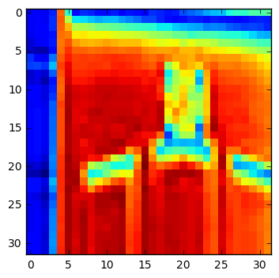

```
[ 0  6 10 10 10 10]
```

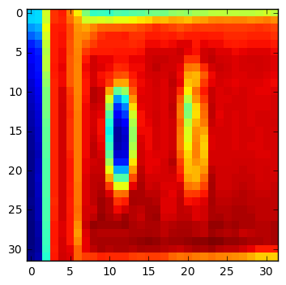

```
[ 0  1 10 10 10 10]
```

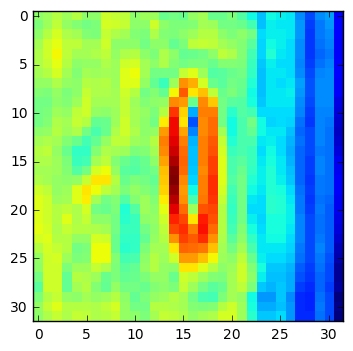

```
[ 0  1  1 10 10 10]
```

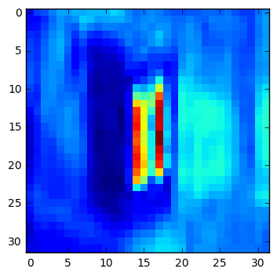

```
Pickling data...
Test samples: (5, 32, 32, 1)
Test labels: (5, 6)
Test bboxes: (5, 6)
Success!
Compressed pickle size: 20994
```

```python
img_width = 32
img_height = 32

# import modules

import cv2
import numpy as np
import os
import random
import sys
import gzip
import idx2numpy
import matplotlib.pyplot as plt
from IPython.display import display
from scipy import ndimage
from scipy.misc import imsave
from sklearn.linear_model import LogisticRegression
from six.moves.urllib.request import urlretrieve
from six.moves import cPickle as pickle
from socket import socket
from PIL import Image

# resize data to 32 x 32

orig_data = './my_data/orig/'

bw_data = './my_data/bw/'
if not os.path.isdir(bw_data):
    print ('Creating dir:', bw_data)
    os.mkdir(bw_data)

resize_data = './my_data/resize/'
if not os.path.isdir(resize_data):
    print ('Creating dir:', resize_data)
    os.mkdir(resize_data)

for i in range(1, 6):
    rd_fname = orig_data + '{}.png'.format(i)
    wr_fname = bw_data + '{}.png'.format(i)
    img = cv2.imread(rd_fname)
    img[img == 255] = 1
    img[img == 0] = 255
    img[img == 1] = 0
    cv2.imwrite(wr_fname, img)

    rd_fname = bw_data + '{}.png'.format(i)
    wr_fname = resize_data + '{}.png'.format(i)
    img = Image.open(rd_fname)

    basewidth = 32
    wpercent = (basewidth / float(img.size[0]))
    hsize = int((float(img.size[1]) * float(wpercent)))
    img = img.resize((32, 32), Image.ANTIALIAS)
    img.save(wr_fname)

# load data

my_labels = np.ndarray(shape=(5, 6), dtype=np.int32)
my_bboxes = np.ndarray(shape=(5, 6), dtype=np.float32)
my_data = np.ndarray(shape=(5, 32, 32), dtype=np.float32)

for i in range(5):
    fname = resize_data + '{}.png'.format(i+1)
    img = Image.open(fname).convert('L')
    my_data[i,:,:] = np.array(img)

my_data = np.expand_dims(my_data, axis=3)

my_labels[0,:] = [0,5,10,10,10,10]
my_labels[1,:] = [0,2,1,0,10,10]
my_labels[2,:] = [0,6,10,10,10,10]
my_labels[3,:] = [0,1,10,10,10,10]
my_labels[4,:] = [0,1,1,10,10,10]

my_bboxes[0,:] = [0,4,41,40,64,0]
my_bboxes[1,:] = [0,2,95,34,136,0]
my_bboxes[2,:] = [0,4,59,24,73,0]
my_bboxes[3,:] = [0,4,30,25,47,0]
my_bboxes[4,:] = [0,3,41,30,75,0]

def display_samples(data, labels, idx):
    print labels[idx]
    plt.imshow(np.squeeze(data[idx], axis=(2,)), interpolation='nearest')
    plt.show()

if idisplay:
    display_samples(my_data, my_labels, 0)
    display_samples(my_data, my_labels, 1)
    display_samples(my_data, my_labels, 2)
    display_samples(my_data, my_labels, 3)
    display_samples(my_data, my_labels, 4)

# Create Pickling File
print('Pickling data...')
pickle_file = 'my_data/my_data.pickle'

print 'Test samples: {}'.format(my_data.shape)
print 'Test labels: {}'.format(my_labels.shape)
print 'Test bboxes: {}'.format(my_bboxes.shape)

try:
    f = open(pickle_file, 'wb')
    save = {'my_data': my_data, 'my_labels': my_labels, 'my_bboxes': my_bboxes}
    pickle.dump(save, f, pickle.HIGHEST_PROTOCOL)
    f.close()
except Exception as e:
    print('Unable to save data to {}: {}'.format(pickle_file, e))
    raise

statinfo = os.stat(pickle_file)
print('Success!')
print('Compressed pickle size: {}'.format(statinfo.st_size))
```

### Question 7

*Choose five candidate images of numbers you took from around you and provide them in the report. Are there any particular qualities of the image(s) that might make classification difficult?*

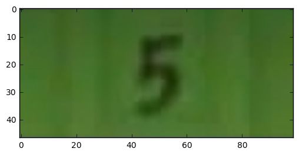

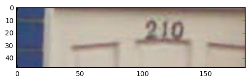

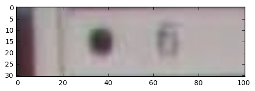

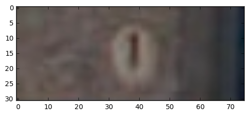

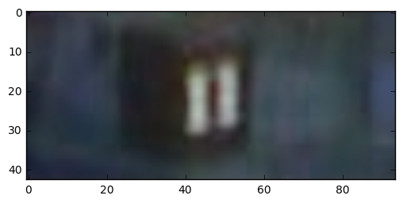

```python
for i in range(1,6):
    rd_fname = 'my_data/orig/{}.png'.format(i)

    img_orig = cv2.imread(rd_fname)
    plt.imshow(img_orig)
    plt.show()
```

**Answer:**

**Did you do any preprocessing on your found images?**

**Are there any particular qualities of the image(s) that might make classification difficult?**

Below are the test results. Some of the images are blurry and difficult to classify

### Question 8

*Is your model able to perform equally well on captured pictures or a live camera stream when compared to testing on the realistic dataset?*

**Answer:**

The model performs reasonably well on few test images.

> > submission/mydata.run.log

**Please summarize what you find relevant from submission/mydata.run.log**

**Test accuracy: 68.0%**

[output not shown]

### Optional: Question 9

*If necessary, provide documentation for how an interface was built for your model to load and classify newly-acquired images.*

**Answer:** Leave blank if you did not complete this part.

### Step 4: Explore an Improvement for a Model

There are many things you can do once you have the basic classifier in place. One example would be to also localize where the numbers are on the image. The SVHN dataset provides bounding boxes that you can tune to train a localizer. Train a regression loss to the coordinates of the bounding box, and then test it.

### Implementation

Use the code cell (or multiple code cells, if necessary) to implement the first step of your project. Once you have completed your implementation and are satisfied with the results, be sure to thoroughly answer the questions that follow.

```
image 1: true bounding box
```

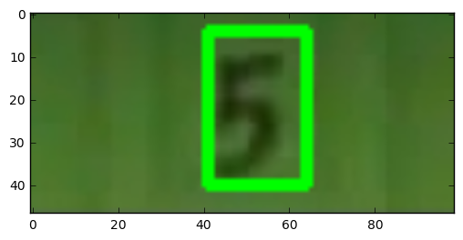

```
image 1: predicted bounding box
```

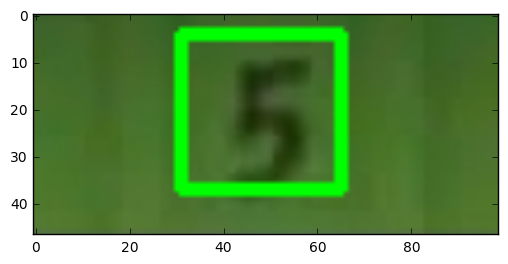

```
image 2: true bounding box
```

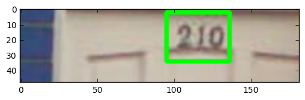

```
image 2: predicted bounding box
```

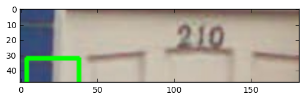

```
image 3: true bounding box
```

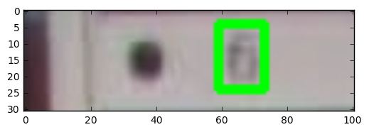

```
image 3: predicted bounding box
```

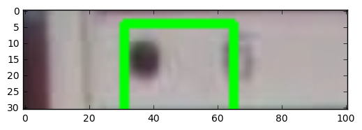

```
image 4: true bounding box
```

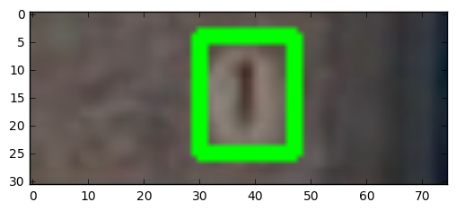

```
image 4: predicted bounding box
```

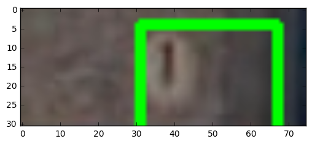

```
image 5: true bounding box
```

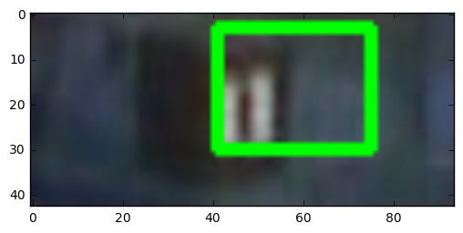

```
image 5: predicted bounding box
```

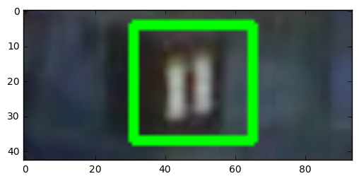

```python
dataset_orig = np.ndarray([100,32,32,1], dtype='float32')
bboxes = np.zeros([100,6], dtype='int32')
bbox_orig = [ [64, 40, 41, 4], [136, 34, 95, 2], [73, 24, 59, 4], [47, 25, 30, 4], [75, 30, 41, 3] ]
bbox_pred = [ [65, 37, 31, 4], [4, 32, 38, 67], [65, 37, 31, 4], [67, 38, 31, 4], [65, 37, 31, 4] ]

for i in range(1,6):
    rd_fname = 'my_data/orig/{}.png'.format(i)
    wr_fname = 'my_data/localized/{}.png'.format(i)

    print 'image {}: true bounding box'.format(i)
    img_orig = cv2.imread(rd_fname)
    cv2.rectangle(img_orig,(bbox_orig[i-1][0],bbox_orig[i-1][1]),(bbox_orig[i-1][2],bbox_orig[i-1][3]),(0,255,0),2)
    plt.imshow(img_orig)
    plt.show()

    print 'image {}: predicted bounding box'.format(i)
    img_pred = cv2.imread(rd_fname)
    cv2.rectangle(img_pred,(bbox_pred[i-1][0],bbox_pred[i-1][1]),(bbox_pred[i-1][2],bbox_pred[i-1][3]),(0,255,0),2)
    plt.imshow(img_pred)
    plt.show()

    cv2.imwrite(wr_fname, img_pred)
```

### Question 10

*How well does your model localize numbers on the testing set from the realistic dataset? Do your classification results change at all with localization included?*

**Answer:**

**How well does your model localize numbers on the testing set from the realistic dataset?**

- The model performs reasonably well to localize the numbers, has a test accuracy of 68%. Accuracy varies depending on the type if images. Model performs badly on images with special features.

**Do your classification results change at all with localization included?**

- No the classification result does not change with localization included
- The model can only do classification or regression/localization for a given run. The selection is based on certain variables being defined
- The model used for classification and localization is same until the point of dense layer (fully connected layer) beyond which the classification uses softmax (5 digits x 10 outputs per digit) where as localization is a regression prediction model which predicts 4 outputs (the 4 four corners of the bounding box).

### Question 11

*Test the localization function on the images you captured in **Step 3**. Does the model accurately calculate a bounding box for the numbers in the images you found? If you did not use a graphical interface, you may need to investigate the bounding boxes by hand.* Provide an example of the localization created on a captured image.

**Answer:**

**Does the model accurately calculate a bounding box for the numbers in the images you found?**

- The model does a decent job to calculate bounding box. Based on the type of the image and extra features present in the image, sometimes the predicted bounding box is off from the true bounding box as can be observed from Image2 where the predicted bounding box is far off from the digits

**Provide an example of the localization created on a captured image.**

- Example 1 below where bounding box is predicted correctly
- Example 2 below where bounding box is predicted in-correctly

```
image 1: predicted bounding box (correct)
```

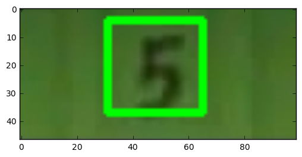

```
image 2: predicted bounding boxm (incorrect)
```

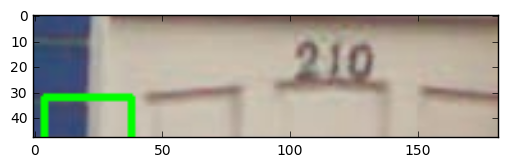

```python
fname = 'my_data/localized/1.png'
print 'image 1: predicted bounding box (correct)'
img_pred = cv2.imread(fname)
cv2.rectangle(img_pred,(bbox_pred[0][0],bbox_pred[0][1]),(bbox_pred[0][2],bbox_pred[0][3]),(0,255,0),2)
plt.imshow(img_pred)
plt.show()

fname = 'my_data/localized/2.png'
print 'image 2: predicted bounding boxm (incorrect)'
img_pred = cv2.imread(fname)
cv2.rectangle(img_pred,(bbox_pred[1][0],bbox_pred[1][1]),(bbox_pred[1][2],bbox_pred[1][3]),(0,255,0),2)
plt.imshow(img_pred)
plt.show()
```

## Optional Step 5: Build an Application or Program for a Model

Take your project one step further. If you're interested, look to build an Android application or even a more robust Python program that can interface with input images and display the classified numbers and even the bounding boxes. You can for example try to build an augmented reality app by overlaying your answer on the image like the [Word Lens](https://en.wikipedia.org/wiki/Word_Lens) app does.

Loading a TensorFlow model into a camera app on Android is demonstrated in the [TensorFlow Android demo app](https://github.com/tensorflow/tensorflow/tree/master/tensorflow/examples/android), which you can simply modify.

If you decide to explore this optional route, be sure to document your interface and implementation, along with significant results you find. You can see the additional rubric items that you could be evaluated on by [following this link](https://review.udacity.com/#!/rubrics/413/view).

### Optional Implementation

Use the code cell (or multiple code cells, if necessary) to implement the first step of your project. Once you have completed your implementation and are satisfied with the results, be sure to thoroughly answer the questions that follow.

```python
### Your optional code implementation goes here.
### Feel free to use as many code cells as needed.
```

### Documentation

Provide additional documentation sufficient for detailing the implementation of the Android application or Python program for visualizing the classification of numbers in images. It should be clear how the program or application works. Demonstrations should be provided.

*Write your documentation here.*

> **Note**: Once you have completed all of the code implementations and successfully answered each question above, you may finalize your work by exporting the iPython Notebook as an HTML document. You can do this by using the menu above and navigating to  
> **File -> Download as -> HTML (.html)**. Include the finished document along with this notebook as your submission.